# Biostat 203B Homework 2

Due Feb 5 @ 11:59PM

```r
knitr::opts_chunk$set(echo = TRUE, cache = TRUE)
library(tidyverse)
library(data.table)
library(lubridate)
os <- sessionInfo()$running
if (str_detect(os, "Linux")) {
  mimic_path <- "/usr/203b-data/mimic-iv"
} else if (str_detect(os, "macOS")) {
  mimic_path <- "/Users/haoyun/Documents/Box Sync/MIMIC/mimic-iv-0.4"
}
```

Use tidyverse (ggpot2, dplyr) to explore the [MIMIC-IV](https://mimic-iv.mit.edu) data introduced in [homework 1](https://ucla-biostat203b-2021winter.github.io/hw/hw1/hw1.html).

```r
system(str_c("tree -s -L 2 ", shQuote(mimic_path)), intern = TRUE)
```

```
##  [1] "/usr/203b-data/mimic-iv"
##  [2] "├── [         78]  core"
##  [3] "│   ├── [   17224843]  admissions.csv.gz"
##  [4] "│   ├── [    2884996]  patients.csv.gz"
##  [5] "│   └── [   51188147]  transfers.csv.gz"
##  [6] "├── [       4096]  hosp"
##  [7] "│   ├── [     430049]  d_hcpcs.csv.gz"
##  [8] "│   ├── [   26575586]  diagnoses_icd.csv.gz"
##  [9] "│   ├── [     723633]  d_icd_diagnoses.csv.gz"
## [10] "│   ├── [     564422]  d_icd_procedures.csv.gz"
## [11] "│   ├── [      14845]  d_labitems.csv.gz"
## [12] "│   ├── [   12913088]  drgcodes.csv.gz"
## [13] "│   ├── [  518077567]  emar.csv.gz"
## [14] "│   ├── [  479709397]  emar_detail.csv.gz"
## [15] "│   ├── [    1415469]  hcpcsevents.csv.gz"
```

[output cut: 20 more lines]

## Q1. PhysioNet credential

At this moment, you should already get credentialed on the PhysioNet. Please include a screenshot of your `Data Use Agreement for the MIMIC-IV (v0.4)`.

[figure not shown]

## Q2. `read.csv` (base R) vs `read_csv` (tidyverse) vs `fread` (data.table)

There are quite a few utilities in R for reading data files. Let us test the speed of reading a moderate sized compressed csv file, `admissions.csv.gz`, by three programs: `read.csv` in base R, `read_csv` in tidyverse, and `fread` in the popular data.table package. Is there any speed difference?

In this homework, we stick to the tidyverse.

```r
system.time(read_csv(str_c(mimic_path, "/core/admissions.csv.gz")))
```

```
##    user  system elapsed
##   4.764   0.695   6.308
```

```r
system.time(read.csv(str_c(mimic_path, "/core/admissions.csv.gz")))
```

```
##    user  system elapsed
##  43.704   0.679  44.431
```

```r
system.time(fread("/usr/203b-data/mimic-iv/core/admissions.csv.gz"))
```

```
##    user  system elapsed
##   2.388   0.226   1.684
```

## Q3. ICU stays

`icustays.csv.gz` (https://mimic-iv.mit.edu/docs/datasets/icu/icustays/) contains data about Intensive Care Units (ICU) stays. Summarize following variables using appropriate numerics or graphs:

- how many unique `stay_id`?
- how many unique `subject_id`?
- length of ICU stay
- first ICU unit
- last ICU unit

*Solutions*

```r
icustays_tble <- read_csv(str_c(mimic_path, "/icu/icustays.csv.gz")) %>%
  print(width = Inf)
```

```
## # A tibble: 69,619 x 8
##    subject_id  hadm_id  stay_id first_careunit
##         <dbl>    <dbl>    <dbl> <chr>
##  1   17823467 27561644 35964304 Coronary Care Unit (CCU)
##  2   15772648 26147926 39637383 Trauma SICU (TSICU)
##  3   13713711 25848902 36363748 Trauma SICU (TSICU)
##  4   13173210 22338446 38210858 Coronary Care Unit (CCU)
##  5   10213765 28522861 39765853 Trauma SICU (TSICU)
##  6   17530304 21776160 35848367 Trauma SICU (TSICU)
##  7   10297774 20364526 37788595 Coronary Care Unit (CCU)
##  8   16766597 21185791 39262919 Trauma SICU (TSICU)
##  9   17684317 28656350 36989766 Trauma SICU (TSICU)
## 10   15693895 21203492 34766377 Surgical Intensive Care Unit (SICU)
##    last_careunit                       intime              outtime
##    <chr>                               <dttm>              <dttm>
```

[output cut: 23 more lines]

1.unique `stay_id`

```r
icustays_tble %>%
  distinct(stay_id) %>%
  nrow ()
```

```
## [1] 69619
```

2.unique`subject_id`

```r
icustays_tble %>%
  distinct(subject_id) %>%
  nrow ()
```

```
## [1] 50048
```

3.length of icu stay

[figure not shown]

```r
icustays_tble %>%
  ggplot(mapping = aes(x = log(los))) +
  geom_histogram(aes(y = ..density..), fill = "orange", colour = "yellow") +
  xlab("length of stay(days)") +
  ylab("Density of total ICU stay")
```

4.first icu unit

```r
icustays_tble %>%
  count(first_careunit)
```

```
## # A tibble: 11 x 2
##    first_careunit                                       n
##    <chr>                                            <int>
##  1 Cardiac Vascular Intensive Care Unit (CVICU)     10920
##  2 Coronary Care Unit (CCU)                          7985
##  3 Medical Intensive Care Unit (MICU)               15587
##  4 Medical/Surgical Intensive Care Unit (MICU/SICU) 12206
##  5 Medicine                                            11
##  6 Neuro Intermediate                                1240
##  7 Neuro Stepdown                                     861
##  8 Neuro Surgical Intensive Care Unit (Neuro SICU)   1558
##  9 PACU                                                68
## 10 Surgical Intensive Care Unit (SICU)              10915
## 11 Trauma SICU (TSICU)                               8268
```

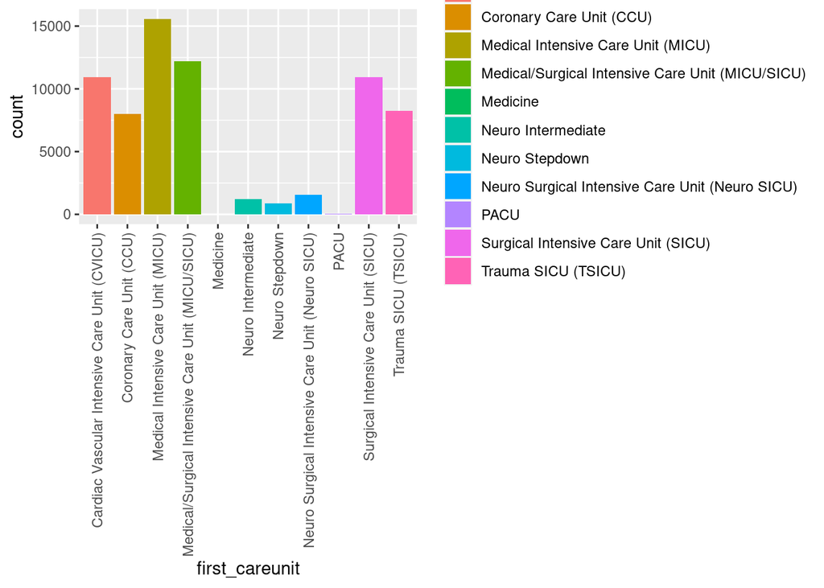

```r
ggplot(data = icustays_tble) +
  geom_bar(mapping = aes(x = first_careunit, fill = first_careunit)) +
  theme(axis.text.x = element_text(angle = 90, vjust = 0.5, hjust = 1))
```

5.last icu unit

```r
icustays_tble %>%
  count(last_careunit)
```

```
## # A tibble: 9 x 2
##   last_careunit                                        n
##   <chr>                                            <int>
## 1 Cardiac Vascular Intensive Care Unit (CVICU)     10946
## 2 Coronary Care Unit (CCU)                          7859
## 3 Medical Intensive Care Unit (MICU)               16221
## 4 Medical/Surgical Intensive Care Unit (MICU/SICU) 12069
## 5 Neuro Intermediate                                1663
## 6 Neuro Stepdown                                    1200
## 7 Neuro Surgical Intensive Care Unit (Neuro SICU)    906
## 8 Surgical Intensive Care Unit (SICU)              10874
## 9 Trauma SICU (TSICU)                               7881
```

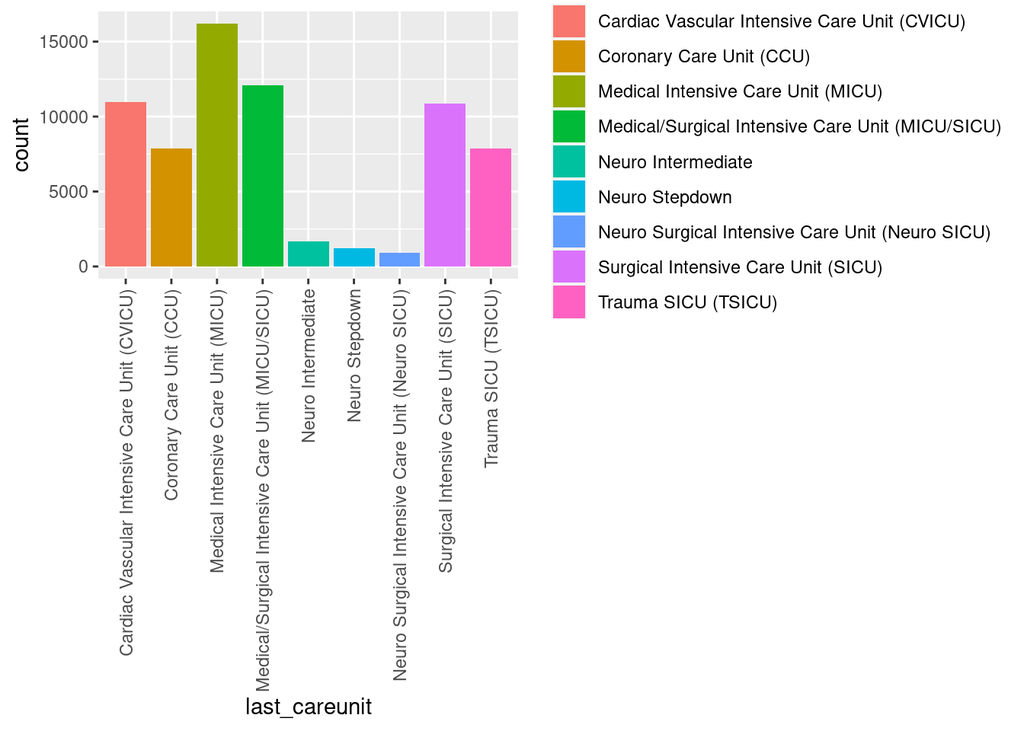

```r
ggplot(data = icustays_tble) +
  geom_bar(mapping = aes(x = last_careunit, fill = last_careunit)) +
   theme(axis.text.x = element_text(angle = 90, vjust = 0.5, hjust = 1))
```

## Q4. `admission` data

Information of the patients admitted into hospital is available in `ADMISSION.csv.gz`. See https://mimic-iv.mit.edu/docs/datasets/core/admissions/ for details of each field in this file. Summarize following variables using appropriate graphs. Explain any patterns you observe.

- admission year
- admission month
- admission month day
- admission week day
- admission hour (anything unusual?)
- number of deaths in each year
- admission type
- number of admissions per patient
- admission location
- discharge location
- insurance
- language
- martial status
- ethnicity
- death

Note it is possible that one patient (uniquely identified by the `SUBJECT_ID`) is admitted into hospital multiple times. When summarizing some demographic information, it makes sense to summarize based on unique patients.

```r
admission <- read_csv(str_c(mimic_path, "/core/admissions.csv.gz")) %>%
  print(width = Inf)
```

```
## # A tibble: 524,520 x 15
##    subject_id  hadm_id admittime           dischtime
##         <dbl>    <dbl> <dttm>              <dttm>
##  1   12427812 21593330 2184-01-06 11:51:00 2184-01-10 11:45:00
##  2   14029832 22059088 2120-01-18 01:28:00 2120-01-20 16:13:00
##  3   14495017 22484010 2175-01-28 15:41:00 2175-01-29 16:00:00
##  4   13676048 23865469 2193-01-19 05:27:00 2193-01-24 18:59:00
##  5   13831972 27763544 2131-01-27 04:03:00 2131-01-27 05:39:00
##  6   18523038 25414328 2142-08-26 17:14:00 2142-08-27 10:00:00
##  7   16705931 20580522 2174-10-24 11:30:00 2174-10-24 18:45:00
##  8   19963742 24951506 2171-07-04 15:58:00 2171-07-05 13:37:00
##  9   10903424 22568585 2181-01-31 13:09:00 2181-01-31 13:42:00
## 10   15030422 21975876 2149-09-21 23:54:00 2149-09-22 03:59:00
##    deathtime           admission_type         admission_location
##    <dttm>              <chr>                  <chr>
```

[output cut: 35 more lines]

*summarize of the variables related to admission dates (use the data of unique patients)*

```r
admission %>%
  distinct(., subject_id, .keep_all = T) %>%
  mutate(month = month(admittime),
         year = year(admittime),
         weekdays = weekdays(admittime),
         days = day(admittime),
         hours = hour(admittime),
         dyear = year(deathtime)) -> admission.date
```

```r
admission.date %>%
  count(days)
```

```
## # A tibble: 31 x 2
##     days     n
##    <int> <int>
##  1     1  8502
##  2     2  8514
##  3     3  8466
##  4     4  8577
##  5     5  8437
##  6     6  8446
##  7     7  8487
##  8     8  8391
##  9     9  8420
## 10    10  8324
## # … with 21 more rows
```

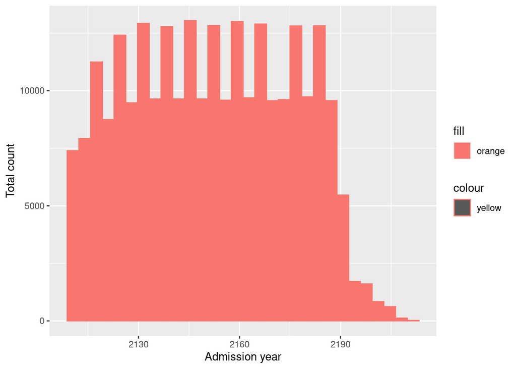

```r
ggplot(data = admission.date) +
  geom_histogram(mapping = aes(x = year, fill = "orange", colour = "yellow")) +
  xlab("Admission year") +
  ylab("Total count")
```

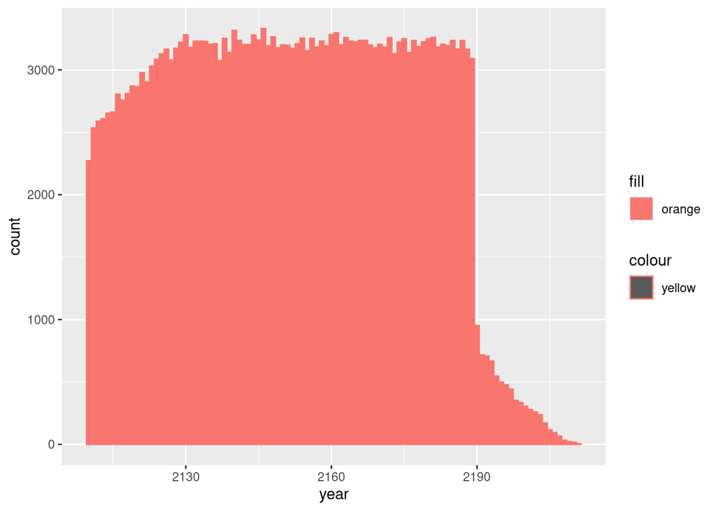

```r
ggplot(data = admission.date) +
  geom_bar(mapping = aes(x = year, fill = "orange", colour = "yellow"))
```

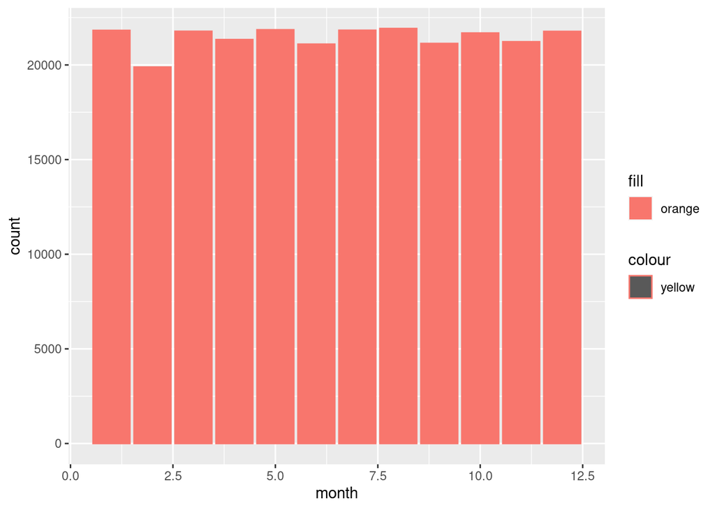

```r
ggplot(data = admission.date) +
  geom_bar(mapping = aes(x = month, fill = "orange", colour = "yellow"))
```

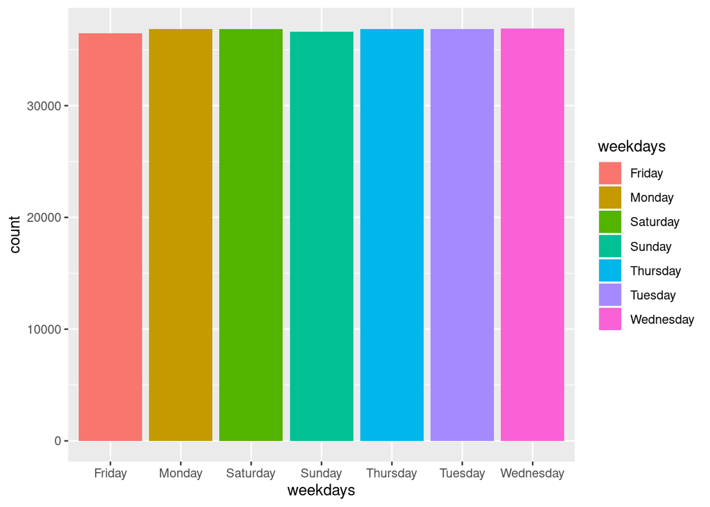

```r
ggplot(data = admission.date) +
  geom_bar(mapping = aes(x = weekdays, fill = weekdays))
```

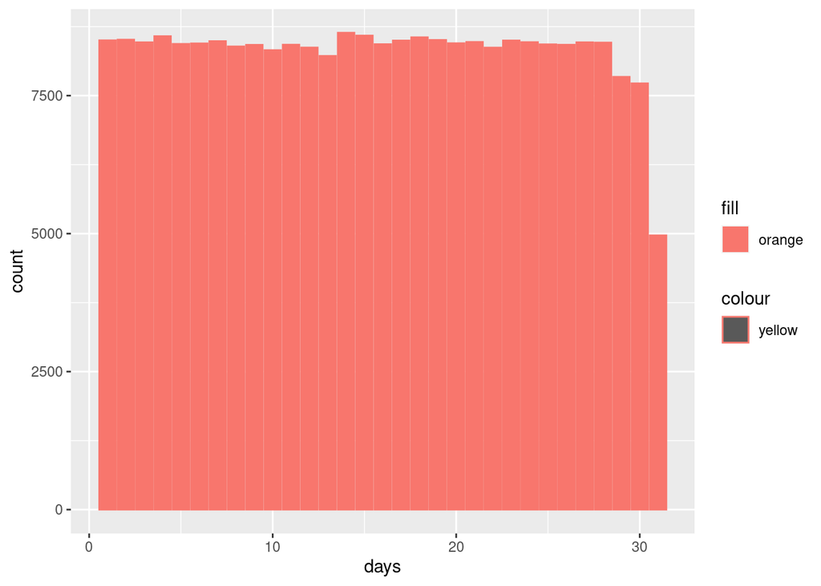

```r
ggplot(data = admission.date) +
  geom_bar(mapping = aes(x = days, fill = "orange", colour = "yellow"))
```

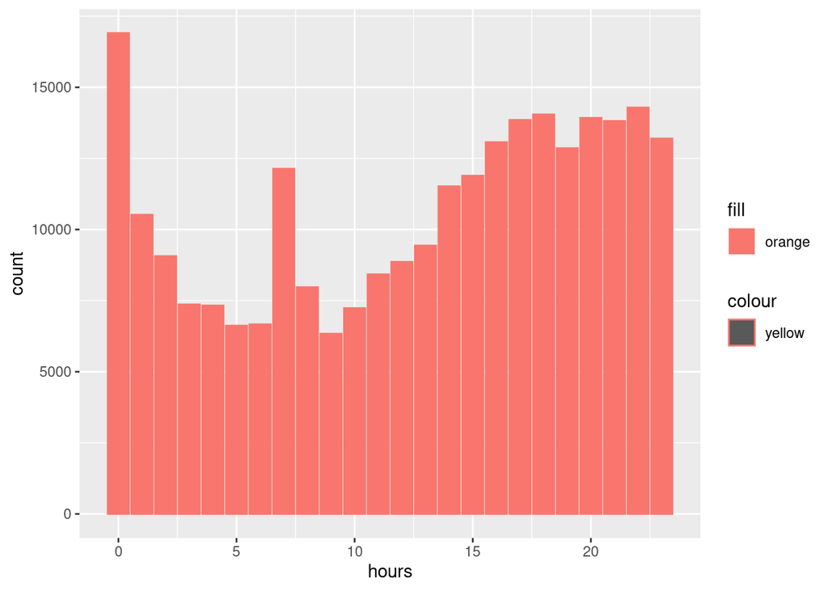

```r
ggplot(data = admission.date) +
  geom_bar(mapping = aes(x = hours, fill = "orange", colour = "yellow"))
```

*number of death in each year* using the `deathtime`

```r
filter(admission.date, !is.na(dyear)) %>%
  nrow ()
```

```
## [1] 5380
```

using the `hospital_expire_flag`

```r
filter(admission.date, hospital_expire_flag == 1) %>%
  count(hospital_expire_flag)
```

```
## # A tibble: 1 x 2
##   hospital_expire_flag     n
##                  <dbl> <int>
## 1                    1  5384
```

*We could find that there’re 4 missing data in the death time, but we could see more details about the more details from `deathtime`,so we choose this variable to do the analysis.*

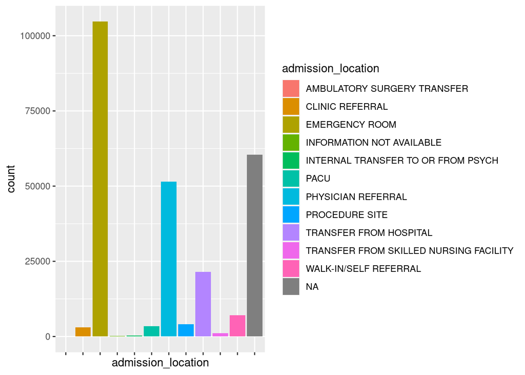

```r
ggplot(data = admission.date) +
  geom_bar(mapping = aes(x = admission_location, fill = admission_location)) +
  theme(axis.text.x = element_blank())
```

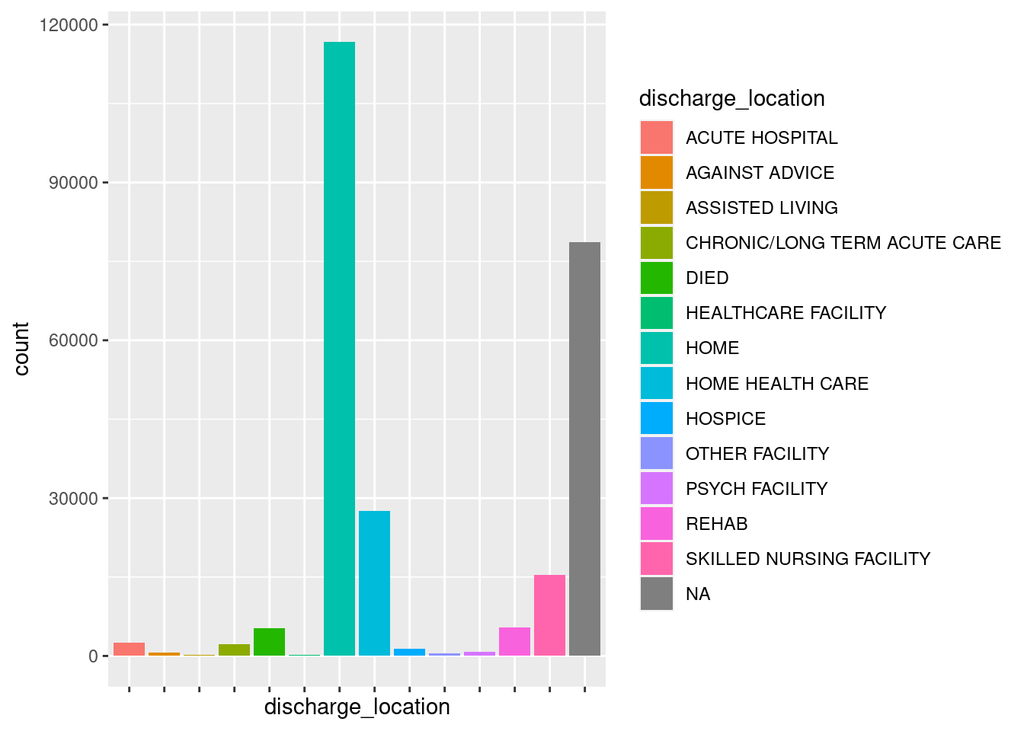

```r
ggplot(data = admission.date) +
  geom_bar(mapping = aes(x = discharge_location, fill = discharge_location)) +
  theme(axis.text.x = element_blank())
```

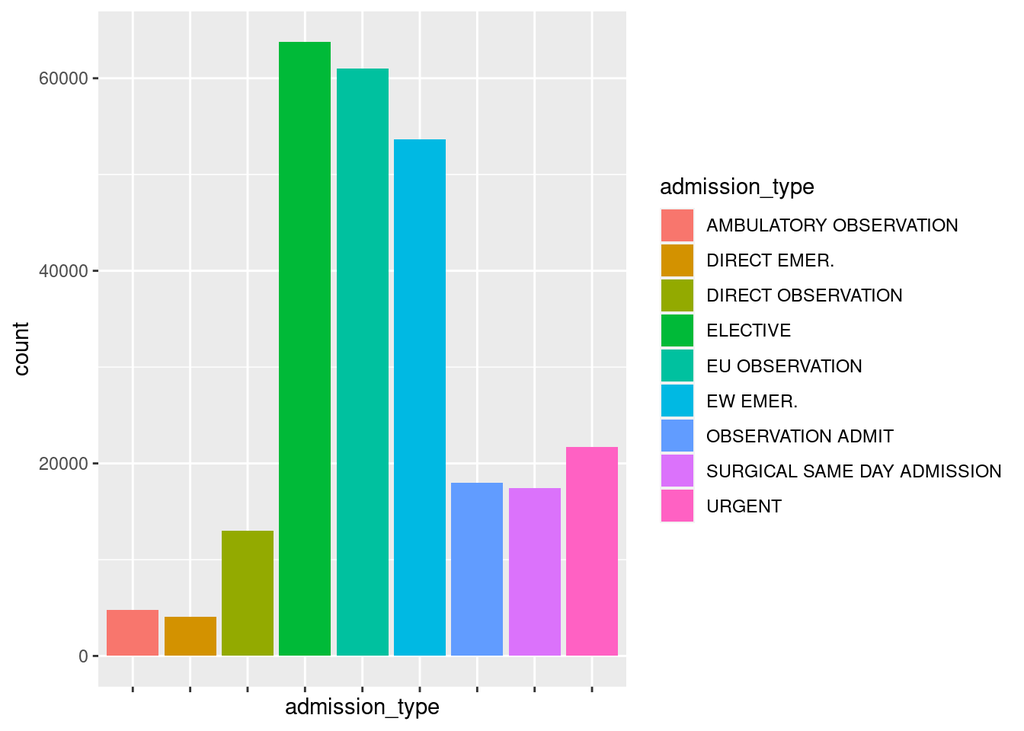

```r
ggplot(data = admission.date) +
  geom_bar(mapping = aes(x = admission_type, fill = admission_type)) +
  theme(axis.text.x = element_blank())
```

*insurance: We could find that the mostly occurred insurance is ‘other’ and medicare occurred more than medicaid.*

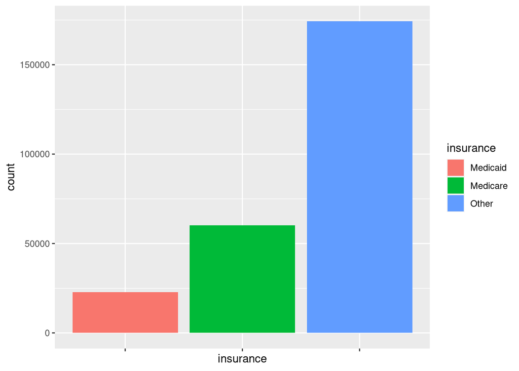

```r
ggplot(data = admission.date) +
  geom_bar(mapping = aes(x = insurance, fill = insurance)) +
  theme(axis.text.x = element_blank())
```

*language: We could find that the mostly occurred language is English.*

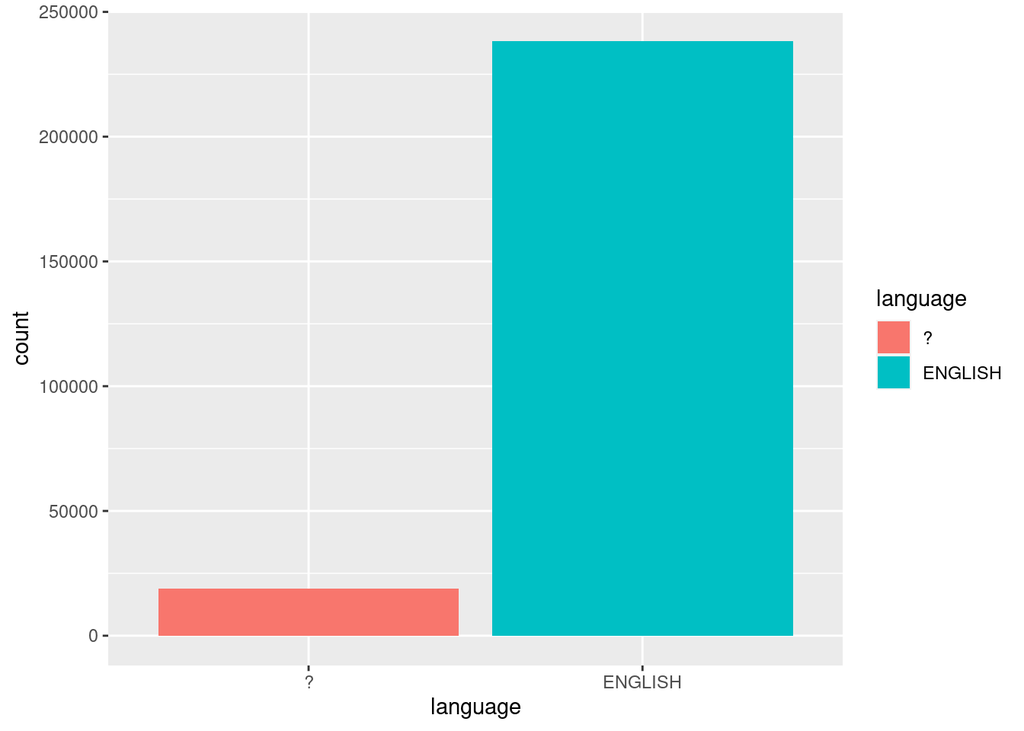

```r
ggplot(data = admission.date) +
  geom_bar(mapping = aes(x = language, fill = language))
```

*marital_status: We could find that the mostly occurred marital status is married.*

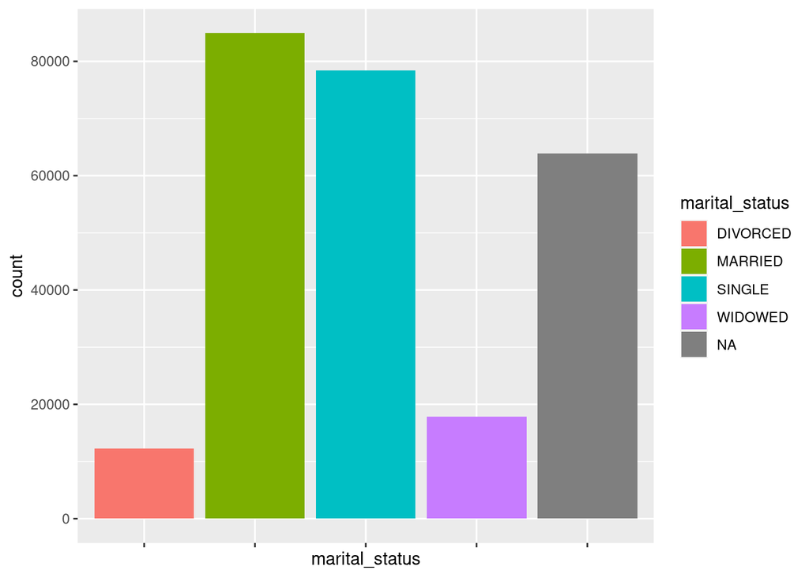

```r
ggplot(data = admission.date) +
  geom_bar(mapping = aes(x = marital_status, fill = marital_status)) +
  theme(axis.text.x = element_blank())
```

*ethnicity: We could find that the mostly occurred ethnicity is White.*

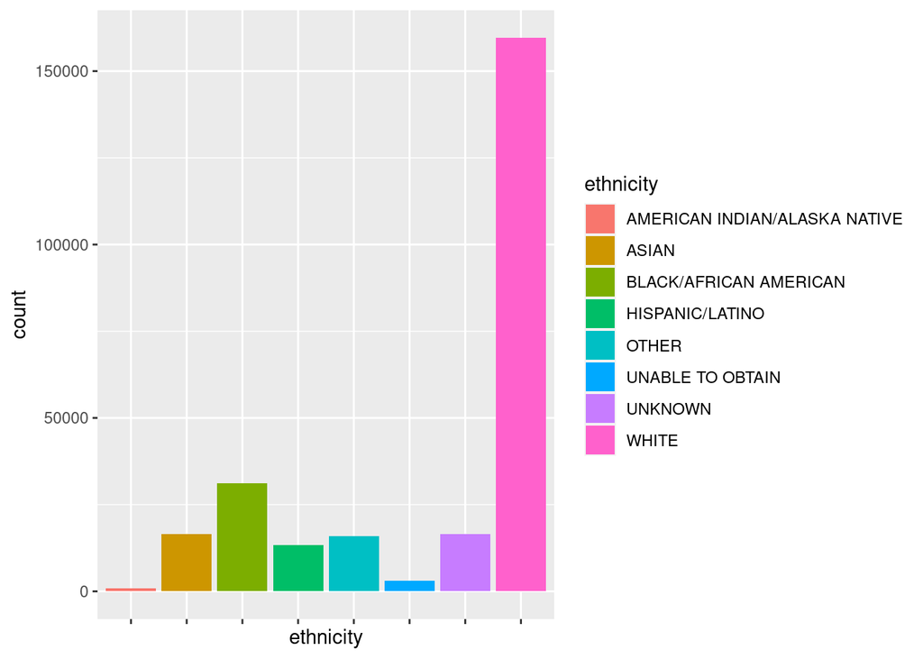

```r
ggplot(data = admission.date) +
  geom_bar(mapping = aes(x = ethnicity, fill = ethnicity)) +
  theme(axis.text.x = element_blank())
```

*The number of admissions per patient is 524520/257366=2.038*

```r
admission %>%
  distinct(hadm_id) %>%
  nrow ()
```

```
## [1] 524520
```

```r
admission %>%
  distinct(subject_id) %>%
  nrow ()
```

```
## [1] 257366
```

*death*

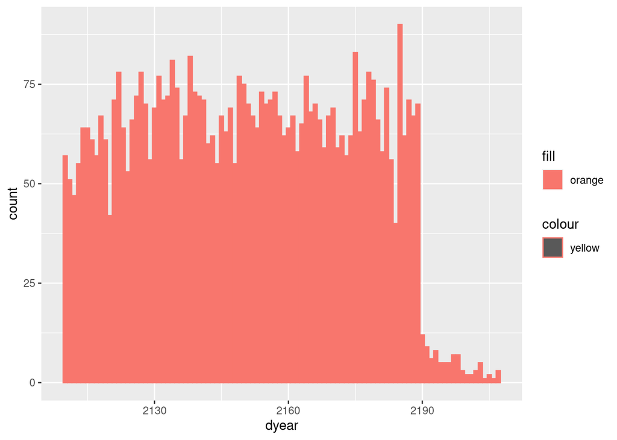

```r
ggplot(data = admission.date) +
  geom_bar(mapping = aes(x = dyear,fill = "orange", colour = "yellow"))
```

*In general, we could find the death distributed uniformly in years,but there’re fewer deaths in the latest years.*

## Q5. `patient` data

Explore `patients.csv.gz` (https://mimic-iv.mit.edu/docs/datasets/core/patients/) and summarize following variables using appropriate numerics and graphs:

- `gender`
- `anchor_age` (explain pattern you see)

```r
patient <- read_csv(str_c(mimic_path, "/core/patients.csv.gz")) %>%
  print(width = Inf)
```

```
## # A tibble: 383,220 x 6
##    subject_id gender anchor_age anchor_year anchor_year_group dod
##         <dbl> <chr>       <dbl>       <dbl> <chr>             <lgl>
##  1   10002723 F               0        2128 2017 - 2019       NA
##  2   10003939 M               0        2184 2008 - 2010       NA
##  3   10004222 M               0        2161 2014 - 2016       NA
##  4   10005325 F               0        2154 2011 - 2013       NA
##  5   10007338 F               0        2153 2017 - 2019       NA
##  6   10008101 M               0        2142 2008 - 2010       NA
##  7   10009872 F               0        2168 2014 - 2016       NA
##  8   10011333 F               0        2132 2014 - 2016       NA
##  9   10011879 M               0        2158 2014 - 2016       NA
## 10   10012663 F               0        2171 2011 - 2013       NA
## # … with 383,210 more rows
```

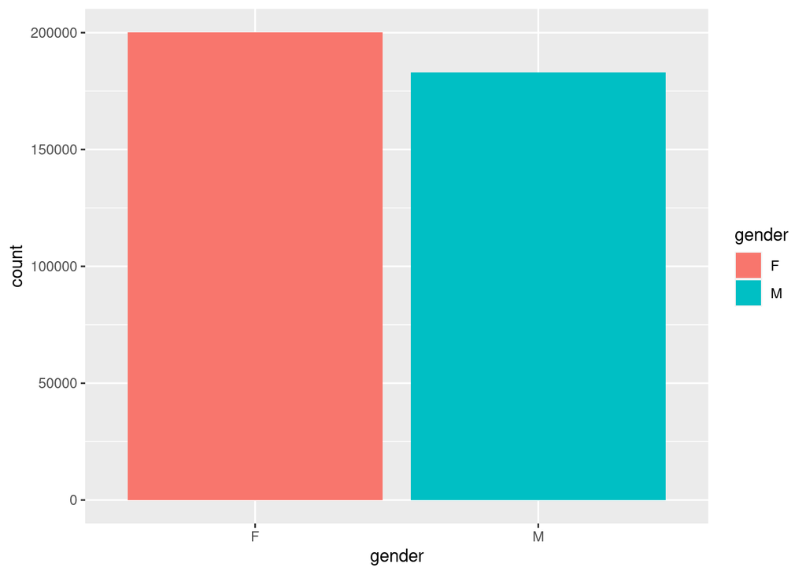

```r
ggplot(data = patient) +
  geom_bar(mapping = aes(x = gender, fill = gender))
```

```r
patient %>%
 count(gender)
```

```
## # A tibble: 2 x 2
##   gender      n
##   <chr>   <int>
## 1 F      200226
## 2 M      182994
```

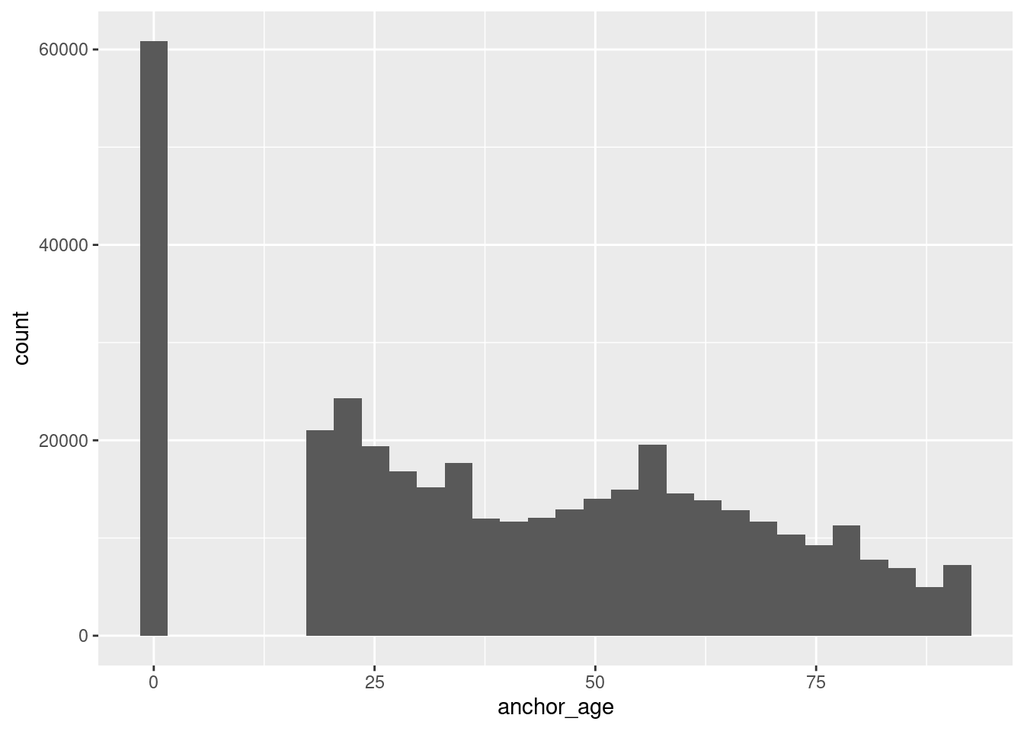

```r
ggplot(data = patient) +
  geom_histogram(mapping = aes(x = anchor_age, fill = anchor_age))
```

```r
patient %>%
 count(anchor_age)
```

```
## # A tibble: 74 x 2
##    anchor_age     n
##         <dbl> <int>
##  1          0 60879
##  2         18  4168
##  3         19  6985
##  4         20  9852
##  5         21  8575
##  6         22  8075
##  7         23  7632
##  8         24  6993
##  9         25  6398
## 10         26  6016
## # … with 64 more rows
```

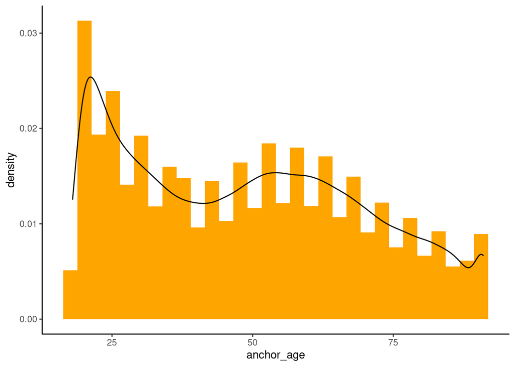

```r
patient %>%
 filter(anchor_age != 0) %>%
  select(anchor_age) %>%
  ggplot(aes(x = anchor_age)) +
  geom_histogram(mapping = aes(y = ..density..), fill = 'orange') +
  geom_density(alpha = 0.6) +
  theme_classic()
```

*Solutions*:From the bar chart,we can figure out that the most patiens has the anchor_age of 0,and there’s no anchor_age between 0-18.The ANCHOR_AGE is the age of the patient in the given ANCHOR_YEAR/ANCHOR_YEAR_SHIFTED.The ‘0’ might refers to the missing data, so we delete the ‘0’ data and analyzed for the rest.

## Q6. Lab results

`labevents.csv.gz` (https://mimic-iv.mit.edu/docs/datasets/hosp/labevents/) contains all laboratory measurements for patients.

We are interested in the lab measurements of creatinine, potassium, sodium, chloride, bicarbonate, hematocrit, white blood cell count, glucose, magnesium, calcium, phosphorus, and lactate. Find the `itemid`s of these lab measurements from `d_labitems.csv.gz` and retrieve a subset of `labevents.csv.gz` only containing these items.

First take a look at the data.

```r
if(!file.exists("labevents_icustays.csv.gz")) {
  system.time(labevents_tab <-
    fread(str_c(mimic_path, "/hosp/labevents.csv.gz"),
          select = c("subject_id", "hadm_id", "itemid",
                     "charttime", "valuenum"), nThread = 4))
  labevents_tab %>%
    semi_join(icustays_tble, by = c("subject_id", "hadm_id")) %>%
    fwrite("labevents_icustays.csv.gz", nThread = 4)
}
system.time(labevents_tab <- fread("labevents_icustays.csv.gz", nThread = 4))
```

```
##    user  system elapsed
##  33.932   3.600  19.414
```

```r
labevents_tab %>%
  as_tibble() %>%
  print(width = Inf)
```

```
## # A tibble: 26,941,051 x 5
##    subject_id  hadm_id itemid charttime           valuenum
##         <int>    <int>  <int> <chr>                  <dbl>
##  1   12457441 21673651  50861 2135-08-16 23:45:00     25
##  2   12457441 21673651  50862 2135-08-16 23:45:00      3.4
##  3   12457441 21673651  50863 2135-08-16 23:45:00    103
##  4   12457441 21673651  50868 2135-08-16 23:45:00     13
##  5   12457441 21673651  50878 2135-08-16 23:45:00    104
##  6   12457441 21673651  50882 2135-08-16 23:45:00     28
##  7   12457441 21673651  50883 2135-08-16 23:45:00      2.1
##  8   12457441 21673651  50884 2135-08-16 23:45:00      2
##  9   12457441 21673651  50885 2135-08-16 23:45:00      4.1
## 10   12457441 21673651  50893 2135-08-16 23:45:00      7.5
## # … with 26,941,041 more rows
```

```r
dlabitems_tble <- read_csv(str_c(mimic_path, "/hosp/d_labitems.csv.gz"))
labitems <- c("creatinine", "potassium", "sodium", "chloride",
             "bicarbonate", "hematocrit", "white blood cell",
             "glucose", "magnesium", "calcium", "lactate")
itemids <- rep(0, length(labitems))
i <- 1
for (labitem in labitems) {
  print(str_interp("search for ${labitem}"))
  itemid_list <- dlabitems_tble %>%
    filter(str_detect(label, regex(labitem, ignore_case = T))) %>%
    .$itemid
  itemid <- labevents_tab %>%
    filter(itemid %in% itemid_list) %>%
    count(itemid) %>%
    arrange(desc(n)) %>%
    slice(1) %>%
    .$itemid
  itemids[i] <- itemid
  i <- i + 1
}
```

```
## [1] "search for creatinine"
## [1] "search for potassium"
## [1] "search for sodium"
## [1] "search for chloride"
## [1] "search for bicarbonate"
## [1] "search for hematocrit"
## [1] "search for white blood cell"
## [1] "search for glucose"
## [1] "search for magnesium"
## [1] "search for calcium"
## [1] "search for lactate"
```

```r
labitem_itemid <- tibble(itemid = itemids, labitem = labitems) %>%
  print(width = Inf)
```

```
## # A tibble: 11 x 2
##    itemid labitem
##     <dbl> <chr>
##  1  50912 creatinine
##  2  50971 potassium
##  3  50983 sodium
##  4  50902 chloride
##  5  50882 bicarbonate
##  6  51221 hematocrit
##  7  51301 white blood cell
##  8  50931 glucose
##  9  50960 magnesium
## 10  50893 calcium
## 11  50813 lactate
```

```r
labevents_tab<-labevents_tab %>%
  as_tibble()%>%
  #keep the items in itemid
  filter(itemid %in% labitem_itemid$itemid) %>%
  mutate(charttime = ymd_hms(charttime)) %>%
  print(width = Inf)
```

```
## # A tibble: 8,021,352 x 5
##    subject_id  hadm_id itemid charttime           valuenum
##         <int>    <int>  <int> <dttm>                 <dbl>
##  1   12457441 21673651  50882 2135-08-16 23:45:00     28
##  2   12457441 21673651  50893 2135-08-16 23:45:00      7.5
##  3   12457441 21673651  50902 2135-08-16 23:45:00     95
##  4   12457441 21673651  50912 2135-08-16 23:45:00      0.6
##  5   12457441 21673651  50960 2135-08-16 23:45:00      1.5
##  6   12457441 21673651  50971 2135-08-16 23:45:00      3
##  7   12457441 21673651  50983 2135-08-16 23:45:00    133
##  8   12457441 21673651  51221 2135-08-16 23:45:00     14.8
##  9   12457441 21673651  51301 2135-08-16 23:45:00      3.3
## 10   12457441 21673651  50813 2135-08-17 00:02:00      2
## # … with 8,021,342 more rows
```

## Q7. Vitals from chartered events

We are interested in the vitals for ICU patients: heart rate, mean and systolic blood pressure (invasive and noninvasive measurements combined), body temperature, SpO2, and respiratory rate.

`chartevents.csv.gz` (https://mimic-iv.mit.edu/docs/datasets/icu/chartevents/) contains all the charted data available for a patient. During their ICU stay, the primary repository of a patient’s information is their electronic chart. The `ITEMID` variable indicates a single measurement type in the database. The `VALUE` variable is the value measured for `ITEMID`.

`d_items.csv.gz` (https://mimic-iv.mit.edu/docs/datasets/icu/d_items/) is the dictionary for the `ITEMID` in `CHARTEVENTS.csv`. Find potential values of `ITEMID` that correspond to systolic blood pressure, i.e., `LABEL` contains the string `systolic`.

#Gain the itemids

```r
dchartitems_tble <- read_csv(str_c(mimic_path, "/icu/d_items.csv.gz"))
chartitems <- c("heart rate", "blood pressure", "blood pressure",
              "temperature", "SpO2", "respiratory rate")
for(chartitem in chartitems){
  print(str_interp("search for ${chartitem}"))
  dchartitems_tble %>%
    filter(str_detect(label, regex(chartitem,ignore_case = T))) %>%
    print(width = Inf)
}
```

```
## [1] "search for heart rate"
## # A tibble: 3 x 9
##   itemid label                   abbreviation    linksto     category
##    <dbl> <chr>                   <chr>           <chr>       <chr>
## 1 220045 Heart Rate              HR              chartevents Routine Vital Signs
## 2 220046 Heart rate Alarm - High HR Alarm - High chartevents Alarms
## 3 220047 Heart Rate Alarm - Low  HR Alarm - Low  chartevents Alarms
##   unitname param_type lownormalvalue highnormalvalue
##   <chr>    <chr>               <dbl>           <dbl>
## 1 bpm      Numeric                NA              NA
## 2 bpm      Numeric                NA              NA
## 3 bpm      Numeric                NA              NA
## [1] "search for blood pressure"
## # A tibble: 17 x 9
##    itemid label                                    abbreviation
```

[output cut: 163 more lines]

#This way took forever to read the file.

```r
if(!file.exists("chartevents_icu.csv.gz")) {
  system.time(chartevents_tab <-
    fread(str_c(mimic_path, "/icu/chartevents.csv.gz"),
          select = c("subject_id", "hadm_id", "itemid",
                     "charttime", "valuenum"), nThread = 4))
  chartevents_tab %>%
    semi_join(icustays_tble, by = c("subject_id", "hadm_id")) %>%
    fwrite("chartevents_icu.csv.gz", nThread = 4)
}
system.time(chartevents_tab <- fread("chartevents_icu.csv.gz", nThread=4))
chartevents_tab %>%
  as_tibble() %>%
  print(width = Inf)
```

Gain a smaller one data set.

```r
system.time(chartevents_tble <- fread("/usr/203b-data/mimic-iv-derived-data/chartevents_filtered_itemid.csv.gz",
                                     header = FALSE,
                                     col.names = c("subject_id",
                                                 "hadm_id",
                                                 "stay_id",
                                                 "charttime",
                                                 "itemid",
                                                 "valuenum"),
                                     nThread = 4) %>%
as_tibble() %>%
mutate_at(c("subject_id", "hadm_id", "stay_id", "itemid"), as.numeric) %>%
mutate(charttime = ymd_hms(charttime)) %>%
print(width = Inf))
```

```
## # A tibble: 30,095,996 x 6
##    subject_id  hadm_id  stay_id charttime           itemid valuenum
##         <dbl>    <dbl>    <dbl> <dttm>               <dbl>    <dbl>
##  1   10003700 28623837 35053963 2165-04-24 05:28:00 220179    152
##  2   10003700 28623837 35053963 2165-04-24 05:28:00 220181    110
##  3   10003700 28623837 35053963 2165-04-24 05:30:00 220045     65
##  4   10003700 28623837 35053963 2165-04-24 05:30:00 220210     14
##  5   10003700 28623837 35053963 2165-04-24 05:38:00 223761     97.6
##  6   10003700 28623837 35053963 2165-04-24 06:00:00 220045     56
##  7   10003700 28623837 35053963 2165-04-24 06:00:00 220179    126
##  8   10003700 28623837 35053963 2165-04-24 06:00:00 220181     88
##  9   10003700 28623837 35053963 2165-04-24 06:00:00 220210     14
## 10   10003700 28623837 35053963 2165-04-24 06:09:00 220045     55
## # … with 30,095,986 more rows
```

```
##    user  system elapsed
##  61.646   6.010  40.608
```

## Q8. Putting things together

Let us create a tibble for all ICU stays, where rows are

- first ICU stay of each unique patient
- adults (age at admission > 18)

and columns contains at least following variables

- all variables in `icustays.csv.gz`
- all variables in `admission.csv.gz`
- first lab measurements during ICU stay
- first vitals measurement during ICU stay
- an indicator variable whether the patient died within 30 days of hospital admission

```r
icustays_uniq_tble <- icustays_tble %>%
  # take first icu stay of each unique patient
  group_by(subject_id) %>%
  filter(rank(intime) == 1) %>%
  ungroup() %>%
  #slice_min(intime) %>% (takes forever)
  #merge admissions table
  left_join(admission, by = c("subject_id", "hadm_id")) %>%
  # merge
  left_join(patient, by = "subject_id") %>%
  # only keep adults
  mutate(age_at_adm = year(admittime) - anchor_year + anchor_age) %>%
  filter(age_at_adm >= 18) %>%
  print(width = Inf)
```

```
## # A tibble: 50,048 x 27
##    subject_id  hadm_id  stay_id first_careunit
##         <dbl>    <dbl>    <dbl> <chr>
##  1   13713711 25848902 36363748 Trauma SICU (TSICU)
##  2   13173210 22338446 38210858 Coronary Care Unit (CCU)
##  3   10213765 28522861 39765853 Trauma SICU (TSICU)
##  4   17530304 21776160 35848367 Trauma SICU (TSICU)
##  5   16766597 21185791 39262919 Trauma SICU (TSICU)
##  6   17684317 28656350 36989766 Trauma SICU (TSICU)
##  7   15693895 21203492 34766377 Surgical Intensive Care Unit (SICU)
##  8   13859862 25015072 31891587 Medical/Surgical Intensive Care Unit (MICU/SICU)
##  9   12200371 27271451 32261832 Medical/Surgical Intensive Care Unit (MICU/SICU)
## 10   13307171 21128752 38043905 Neuro Stepdown
##    last_careunit                                    intime
##    <chr>                                            <dttm>
```

[output cut: 83 more lines]

Merge lab results

```r
icustays_tble_lab <- labevents_tab %>%
  semi_join(icustays_uniq_tble, by = c("subject_id","hadm_id")) %>%
  #plus intime column
  left_join(select(icustays_uniq_tble, subject_id, hadm_id, intime),
            by = c("subject_id", "hadm_id")) %>%
  #take the lab items after icu intime
  filter(charttime >= intime) %>%
  #group by itemid
  group_by(subject_id, itemid) %>%
  #only keep the first charttime
  arrange(charttime, .by_group = TRUE) %>%
  slice_head(n = 1) %>%
  #don't need charttime intime
  select(-charttime, -intime) %>%
  spread(key = itemid, value = valuenum) %>%
  #merge with icustays_uniq_tble
  right_join(icustays_uniq_tble, by=c("subject_id", "hadm_id")) %>%
  ungroup() %>%
  #name all the labitems
  rename_at(vars(as.character(labitem_itemid$itemid)),
            ~labitem_itemid$labitem) %>%
  print(width = Inf)
```

```
## # A tibble: 50,048 x 38
##    subject_id  hadm_id lactate bicarbonate calcium chloride creatinine glucose
##         <dbl>    <dbl>   <dbl>       <dbl>   <dbl>    <dbl>      <dbl>   <dbl>
##  1   10000032 29079034    NA            21     9.3      102        0.5     115
##  2   10000980 26913865    NA            23     9.2      103        2.2     144
##  3   10001217 24597018    NA            23     8.2      104        0.4     113
##  4   10001725 25563031    NA            24     9.1      106        0.8     146
##  5   10001884 26184834     1.5          33     9.8       96        1.1     148
##  6   10002013 23581541     3.3          23    NA        109        1.1      98
##  7   10002155 23822395    NA            25     8.8      106        0.9      95
##  8   10002223 22494570    NA            26     8.7      102        0.8      88
##  9   10002428 28662225     1.6          20     7.4       98        0.8      99
## 10   10002443 21329021     1.7          20     7.6      101        0.8     226
##    magnesium potassium sodium hematocrit `white blood cell`  stay_id
##        <dbl>     <dbl>  <dbl>      <dbl>              <dbl>    <dbl>
```

[output cut: 107 more lines]

chartevents

```r
chartevents_uniq_tble <- chartevents_tble %>%
  select(-stay_id) %>%
  print(width = Inf)
```

```
## # A tibble: 30,095,996 x 5
##    subject_id  hadm_id charttime           itemid valuenum
##         <dbl>    <dbl> <dttm>               <dbl>    <dbl>
##  1   10003700 28623837 2165-04-24 05:28:00 220179    152
##  2   10003700 28623837 2165-04-24 05:28:00 220181    110
##  3   10003700 28623837 2165-04-24 05:30:00 220045     65
##  4   10003700 28623837 2165-04-24 05:30:00 220210     14
##  5   10003700 28623837 2165-04-24 05:38:00 223761     97.6
##  6   10003700 28623837 2165-04-24 06:00:00 220045     56
##  7   10003700 28623837 2165-04-24 06:00:00 220179    126
##  8   10003700 28623837 2165-04-24 06:00:00 220181     88
##  9   10003700 28623837 2165-04-24 06:00:00 220210     14
## 10   10003700 28623837 2165-04-24 06:09:00 220045     55
## # … with 30,095,986 more rows
```

```r
icustays_lab_chart <- chartevents_uniq_tble %>%
  semi_join(icustays_tble_lab, by = c("subject_id","hadm_id")) %>%
  #plus intime column
  left_join(select(icustays_tble_lab, subject_id, hadm_id, intime),
            by = c("subject_id", "hadm_id")) %>%
  #take the chart items after icu intime
  filter(charttime >= intime) %>%
  #group by itemid
  group_by(subject_id, itemid) %>%
  #only keep the first charttime
  arrange(charttime, .by_group = TRUE) %>%
  slice_head(n = 1) %>%
  #don't need charttime intime
  select(-charttime, -intime) %>%
  spread(key = itemid, value = valuenum) %>%
  #merge with icustays_tble_lab
  right_join(icustays_tble_lab, by = c("subject_id", "hadm_id")) %>%
  ungroup() %>%
  print(width = Inf)
```

```
## # A tibble: 50,048 x 45
##    subject_id  hadm_id `220045` `220050` `220052` `220179` `220181` `220210`
##         <dbl>    <dbl>    <dbl>    <dbl>    <dbl>    <dbl>    <dbl>    <dbl>
##  1   10000032 29079034       91       NA       NA       84       56       24
##  2   10000980 26913865       77       NA       NA      150       92       23
##  3   10001217 24597018       86       NA       NA      151      104       18
##  4   10001725 25563031       55       NA       NA       73       59       19
##  5   10001884 26184834       38       NA       NA      180       46       10
##  6   10002013 23581541       80      134       94      104       77       14
##  7   10002155 23822395       68      115       82      126       78       18
##  8   10002223 22494570      100       NA       NA      123       80       29
##  9   10002428 28662225      124      102       69       87       53       25
## 10   10002443 21329021       81       NA       NA      136       99       23
##    `223761` lactate bicarbonate calcium chloride creatinine glucose magnesium
##       <dbl>   <dbl>       <dbl>   <dbl>    <dbl>      <dbl>   <dbl>     <dbl>
```

[output cut: 119 more lines]

*We could find that since there’s no data for the patient to test the Forehead SpO2 Sensor in Place(229862) after entering the icus, so we didn’t have the data of SpO2 for icu patients.*

```r
icustays_lab_chart$Dieday <-
  as.numeric(icustays_lab_chart$deathtime - icustays_lab_chart$admittime)
icustays_lab_chart$Diein30 <- (0 < icustays_lab_chart$Dieday &
                               icustays_lab_chart$Dieday < 43200)
icustays_final <- icustays_lab_chart %>%
  select(-Dieday) %>%
  rename(Heartrate = `220045`, abps = `220050`, abpm = `220052`,
         nbps = `220179`, nbpm = `220181`, respirationrate = `220210`,
         temperature_f = `223761`) %>%
  print(width = Inf)
```

```
## # A tibble: 50,048 x 46
##    subject_id  hadm_id Heartrate  abps  abpm  nbps  nbpm respirationrate
##         <dbl>    <dbl>     <dbl> <dbl> <dbl> <dbl> <dbl>           <dbl>
##  1   10000032 29079034        91    NA    NA    84    56              24
##  2   10000980 26913865        77    NA    NA   150    92              23
##  3   10001217 24597018        86    NA    NA   151   104              18
##  4   10001725 25563031        55    NA    NA    73    59              19
##  5   10001884 26184834        38    NA    NA   180    46              10
##  6   10002013 23581541        80   134    94   104    77              14
##  7   10002155 23822395        68   115    82   126    78              18
##  8   10002223 22494570       100    NA    NA   123    80              29
##  9   10002428 28662225       124   102    69    87    53              25
## 10   10002443 21329021        81    NA    NA   136    99              23
##    temperature_f lactate bicarbonate calcium chloride creatinine glucose
##            <dbl>   <dbl>       <dbl>   <dbl>    <dbl>      <dbl>   <dbl>
```

[output cut: 119 more lines]

*For the variable Diein30,the `NA` means the data is missing (mostly, the patient is still alive), `TRUE`means the patient died in 30 days, `FALSE` means dies after 30days.*